# interpolacja_funkcje_sklejane_fitowanie

## Interpolacja wielomianowa

W zagadnieniu interpolacyjnym szukamy funkcji $w(x)$ przechodzącej przez zadane punkty (np. dane pomiarowe)

\begin{array}{|c|c|c|c|} \hline x_0 & x_1 & \ldots &x_n\\ \hline y_0 & y_1 & \ldots &y_n\\ \hline \end{array}

tzn. $w(x_i)=y_i$, dla $i=0,1,\ldots,n$.

Znająć postać w(x) możemy obliczyć jej wartości dla dowolnych x między węzłami $x_i$

W interpolacji wielomianowej $w(x)$ jest wielomianem stopnia n

$$ w(x)=a_0+a_1x+\ldots+a_{n-1}x^{n-1}+a_{n}x^{n} $$

### Interpolacja Lagranża

Wielomian interpolacyjny można przedstawić w postaci

$$ w(x)=\sum_{i=0}^{i=n}{y_i\phi_i(x)} $$

gdzie $$ \phi_i(x)=\frac{\prod_{j\neq i}{(x-x_j)}}{\prod_{j\neq i}{(x_i-x_j)}} $$

Funkcje $\phi_i$ są wielomianami mającymi tąką właściwość

$$ \phi_i(x_j) = \begin{cases} 1 & \text{dla } j=i\\ 0 & \text{dla } j\neq i \end{cases} $$

Dzięki temu łatwo sprawdzić, że $w(x_i)=y_i$ dla $i=0,1,\ldots,n$.

Przykład.

Dane

\begin{array}{|c|c|c|c|} \hline i & 0& 1 &2\\ \hline x & 0& 1 &3\\ \hline y & 1 & 3 &2\\ \hline \end{array}

Obliczymy $\phi_i(x)$

$$ \phi_0(x)=\frac{(x-x_1)(x-x_2)}{(x_0-x_1)(x_0-x_2)}=\frac{(x-1)(x-3)}{(0-1)(0-3)}= \frac{x^2-4x+3}{3} $$$$ \phi_1(x)=\frac{(x-x_0)(x-x_2)}{(x_1-x_0)(x_1-x_2)}=\frac{(x-0)(x-3)}{(1-0)(1-3)}= \frac{-x^2+3x}{2} $$$$ \phi_2(x)=\frac{(x-x_0)(x-x_1)}{(x_2-x_0)(x_2-x_1)}=\frac{(x-0)(x-1)}{(3-0)(3-1)}= \frac{x^2-x}{6} $$

Postać wielomianu interpolacyjnego

$$w(x)=y_0\phi_0(x)+y_1\phi_1(x)+y_2\phi_2(x)=-\frac{5}{6}x^2+\frac{17}{6}x+1$$

Wykreślimy teraz dane i wielomian interpolacyjny

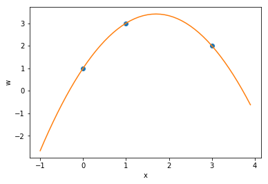

```
w(2)= 3.3333333333333335
```

```python
%matplotlib  inline
import matplotlib.pyplot as plt
import numpy as np
dx=np.array([0,1,3],dtype=float)
dy=np.array([1,3,2],dtype=float)
plt.plot(dx, dy,'o')
xw = np.arange(-1, 4, 0.1)
plt.plot(xw,np.polyval([-5/6,17/6,1], xw))
plt.xlabel('x')
plt.ylabel('w')
plt.show()
print('w(2)=',np.polyval([-5/6,17/6,1], 2))
```

Wykorzystamy teraz funkcję lagrange() z modułu Scipy

https://docs.scipy.org/doc/scipy/reference/generated/scipy.interpolate.lagrange.html

do znalezienia wielomianu interpoalcyjnego dla

\begin{array}{|c|c|c|c|c|c|} \hline i & 0& 1 &2& 3& 4\\ \hline x & 0& 0.5 &1& 1.5 &2\\ \hline y & -1 & 1.5 &4 &5.5&6\\ \hline \end{array}

```python
from scipy.interpolate import lagrange
dx2=np.array([ 0, 0.5, 1, 1.5, 2],dtype=float)
dy2=np.array([-1, 1.5, 4, 5.5, 6],dtype=float)
wl_2 = lagrange(dx2, dy2)

print(wl_2)
print('w(0.7)=',wl_2(0.7))
```

```
        4         3         2
0.6667 x - 3.333 x + 3.833 x + 3.833 x - 1
w(0.7)= 2.5783999999999954
```

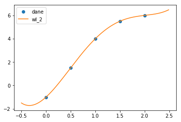

```python
# wykreślimy ten wielomian i dane
plt.plot(dx2, dy2,'o')
xw2 = np.arange(-0.5, 2.5, 0.01)
plt.plot(xw2, wl_2(xw2))
plt.legend(['dane',  'wl_2'], loc='best')
plt.show()
```

Interpolację wielomianową stosujemy do niewielkiej liczby węzłów, zwykle mniejszej od 6, ponieważ dla większej liczby wezłów możemy obserwować oscylacje między węzłami.

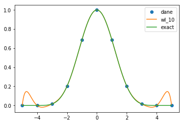

```python
s=5
dx5=np.linspace(-s, s, num=2*s+1, endpoint=True)
dy5=np.cos(dx5*np.pi/(2*s-1))**6
wl_5 = lagrange(dx5, dy5)
plt.plot(dx5, dy5,'o')
xw5 = np.arange(-s, s, 0.01)
plt.plot(xw5, wl_5(xw5))
plt.plot(xw5, np.cos(xw5*np.pi/(2*s-1))**6)
plt.legend(['dane',  'wl_10','exact'], loc='best')
plt.show()
```

Na wykresie widzimy duże oscylacje między końcowymi węzłami. Zobaczymy pózniej, że interpolacja funkcjami sklejanymi trzeciego stopnia daje lepsze rezultaty.

### Metoda Nevilla

Jeśli interesuje nas tylko jedna wartość interpolowanego wielomianu dla ustalonego x, to nie musimy wyznaczać jego współczynników. Jedną z metod która służy do tego celu jest metoda Nevilla.

Oblicza ona rekurencyjne wartości wielomianów interpolacyjnych $w_{i,i+1,...,i+k}(x)$, przechodzących przez punkty $\left( (x_i,y_i),(x_{i+1},y_{i+1}),...,(x_{i+k},y_{i+k}) \right)$, z formuły rekurencyjnej

\begin{equation}\label{eq:nev1} w_{i,...,i+k}(x)= \frac{(x-x_i)w_{i+1,...,i+k}(x)-(x-x_{i+k})w_{i,...,i+k-1}(x)}{x_{i+k}-x_i} \end{equation}

gdzie $w_i(x)=y_i$ dla $i=0,1,...,n$.

Prosty przykład dla n=2

\begin{array}{|c|c|c|c|} \hline i & 0& 1 &2\\ \hline x & 0& 1 &3\\ \hline y & 1 & 3 &2\\ \hline \end{array}

\begin{array}{|c|c|c|c|c|} \hline i &x_i & y_i& w_{i,i+1} &w_{i,i+1,i+2}\\ \hline 0 &0 & 1&w_{0,1} &w_{0,1,2}\\ \hline 1 &1 & 3& w_{1,2}&\\ \hline 2 &3 & 2 & &\\ \hline \end{array}

Najpierw obliczymy $w_{0,1}(2)$

\begin{equation}\label{eq:nev2} w_{0,1}(2)= \frac{(2-x_0)w_{1}-(2-x_{1})w_{0}}{x_{1}-x_0}= \frac{(2-0)3-(2-1)1}{1-0}=5 \end{equation}

Następnie $w_{1,2}(2)$

\begin{equation}\label{eq:nev3} w_{1,2}(2)= \frac{(2-x_1)w_{2}-(2-x_{2})w_{1}}{x_{2}-x_1}= \frac{(2-1)2-(2-3)3}{3-1}=\frac{5}{2} \end{equation}

W końcu obliczymy $w_{0,1,2}(2)$

\begin{equation}\label{eq:nev4} w_{0,1,2}(2)= \frac{(2-x_0)w_{1,2}(2)-(2-x_{2})w_{0,1}(2)}{x_{2}-x_0}= \frac{(2-0)5/2-(2-3)5}{3-0}=\frac{10}{3} \end{equation}

Z tego przykładu widać, że można łatwo zaimplementować tę metodę

```python
# metoda Nevilla
def Nev(ax,ay,x):
    w=ay.copy()
    nw=ax.size
    for k in range (1,nw):
        for i in range(nw-k):
            w[i]=((x-ax[i])*w[i+1]-(x-ax[i+k])*w[i])/(ax[i+k]-ax[i])
    return w[0]
# obliczymy wartość wielomianu interpolacyjnego w x=2
print(Nev(dx,dy,2))
```

```
3.3333333333333335
```

```python
# dla drugiego przykładu z węzłami dx2 i wartościami dy2
# obliczymy wartość wielomianu interpolacyjnego w x=0.7
print(Nev(dx2,dy2,0.7))
```

```
2.5783999999999994
```

## Interpolacja funkcjami sklejanymi

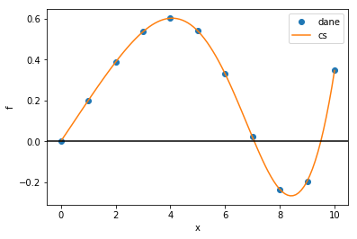

```python
# przykład
from scipy.interpolate import CubicSpline
xw = np.linspace(0, 10, num=11, endpoint=True)
yw=xw/5-1+np.cos((xw/5)**2)
plt.plot(xw, yw,'o')
cs = CubicSpline(xw, yw)
xs = np.linspace(0, 10, num=100, endpoint=True)
plt.plot(xs, cs(xs))
plt.legend(['dane',  'cs'], loc='best')
plt.axhline(y=0,color='k')
plt.xlabel('x')
plt.ylabel('f')
plt.show()
```

W interpolacji funkcjami sklejanymi używa się osobnej funkcji interpolacyjnej $f_i(x)$ w każdym przedziale między kolejnymi węzłami $(x_i, x_{i+1})$ dla $i=0,1,\ldots,n-1$.

W najprostszym przypadku, gdy $f_i(x)$ są liniowe, nieznane parametry wyznacza się z warunku ciągłości

$$f_{i-1}(x_i)=y_i=f_{i}(x_i) $$

Jednak liniowe funkcje nie zapewniają odpowiedniej gadkosci. W praktyce najczęściej stosuje się kubiczne funkcje sklejane, które są wielomianami 3 stopnia. W tym przypadku, oprócz warunków ciągłości funkcji na końcach przedziałów, nakłada się również warunki ciągłości pierwszych i drugich pochodnych funkcji sklejanych w węzłach $x_i$

$$f_{i-1}^{\prime}(x_i)=f_{i}^{\prime}(x_i)$$$$f_{i-1}^{\prime\prime}(x_i)=f_{i}^{\prime\prime}(x_i)$$

Powyższe warunki prowadzą do $4n-2$ równań na $4n$ parametry funkcji sklejanych. Dodatkowe 2 warunki dotyczą węzłów brzegowych $x_0$ i $x_n$, np. w naturalnych funkcjach sklejanych zakłada się znikanie drugich pochodnych w $x_0$ i $x_n$.

Sposób obliczenia parametrów funkcji sklejanych polega na wyrażeniu ich przez nieznane wartości drugich pochodnych w węzłach, $s_i\equiv f_{i}^{\prime\prime}(x_i)$. Korzystając z interpolacji Lagranża można drugą pochodną przedstawić następująco

$$ f_{i}^{\prime\prime}(x)=\frac{x-x_{i+1}}{x_{i}-x_{i+1}}s_{i}+ \frac{x-x_{i}}{x_{i+1}-x_{i}}s_{i+1} $$

Całkując dwukrotnie $f_{i}^{\prime\prime}(x)$ otrzymujemy funkcje sklejane wyrażone przez nieznane $s_i$

$$ f_{i}(x)=\frac{\left(x-x_{i+1}\right)^3s_{i} -\left(x-x_{i}\right)^3s_{i+1}}{6(x_{i}-x_{i+1})}+ A(x-x_{i+1})-B(x-x_{i}) $$ gdzie $$ A=\frac{h_is_i}{6}-\frac{y_i}{h_i}, \;\; B=\frac{h_is_{i+1}}{6}-\frac{y_{i+1}}{h_i}, \;\; h_i=x_{i+1}-x_i $$

Wykorzystując warunek ciągłości pochodnych $f_{i}^\prime(x)$ otrzymujemy układ $n-1$ równań liniowych

$$\left( \begin{matrix} d_{1}&h_{1} & & &\\ h_{1}&d_{2} &h_{2}& &\\ &\ddots &\ddots&\ddots &\\ & &h_{n-3}&d_{n-2}&h_{n-2}\\ & & &h_{n-21}&d_{n-1} \end{matrix}\right) \left( \begin{array}{c} s_1 \\ s_2\\ \vdots \\ s_{n-2}\\ s_{n-1} \end{array}\right) = \left( \begin{array}{c} b_1 \\ b_2\\ \vdots \\ b_{n-2}\\ b_{n-1} \end{array}\right)$$

gdzie $d_i=2(h_{i-1}+h_i)$, $\;\;b_i=6\frac{y_{i+1}-y_{i}}{h_{i}}- 6\frac{y_{i}-y_{i-1}}{h_{i-1}}$

Ten układ rónań liniowych możemy rozwiązać metodą LU lub eliminacji Gaussa.

Wykorzystamy teraz funkcję interp1d()

https://docs.scipy.org/doc/scipy/reference/generated/scipy.interpolate.interp1d.html#scipy.interpolate.interp1d

do interpolacji funkcjami sklejanymi poniższych danych

\begin{array}{|c|c|c|c|c|c|} \hline i & 0& 1 &2& 3& 4\\ \hline x & 0& 0.5 &1& 1.5 &2\\ \hline y & -1 & 1.5 &4 &5.5&6\\ \hline \end{array}

Funkcja interp1d() pozwala stosować różne funkcje sklejane w zależności od wartości parametru kind.

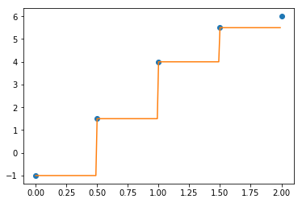

```python
# kind ='zero'
from scipy.interpolate import interp1d
fk0=interp1d(dx2, dy2,kind='zero')
xw2 = np.arange(0.0, 2.0, 0.01)
plt.plot(dx2, dy2,'o')
plt.plot(xw2, fk0(xw2))
plt.show()
```

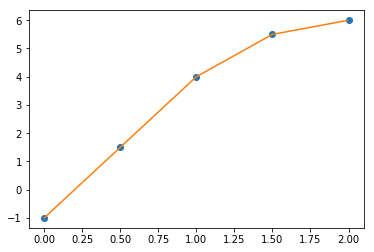

```python
# kind ='linear' domyślna wartość
fk1=interp1d(dx2, dy2,kind='linear')
plt.plot(dx2, dy2,'o')
plt.plot(xw2, fk1(xw2))
plt.show()
```

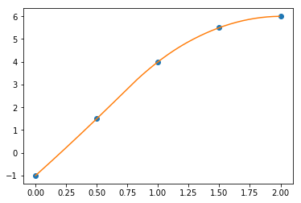

```python
# kind ='quadratic'
fk2=interp1d(dx2, dy2,kind='quadratic')
plt.plot(dx2, dy2,'o')
plt.plot(xw2, fk2(xw2))
plt.show()
```

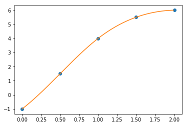

```python
# kind ='cubic'
fk2=interp1d(dx2, dy2,kind='cubic')
plt.plot(dx2, dy2,'o')
plt.plot(xw2, fk2(xw2))
plt.show()
```

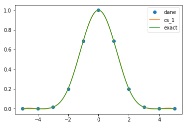

```python
# Teraz zastosujemy funkcje sklejane kind='cubic'
# do przykładu, w którym interpolacja Lagranża prowadzi do oscylacji między węzłami


cs_1 = interp1d(dx5, dy5,kind='cubic')
plt.plot(dx5, dy5,'o')
plt.plot(xw5, cs_1(xw5))
plt.plot(xw5, np.cos(xw5*np.pi/(2*s-1))**6)
plt.legend(['dane',  'cs_1','exact'], loc='best')
plt.show()
```

Przetestujemy teraz funkcję CubicSpline() z Scipy

https://docs.scipy.org/doc/scipy/reference/generated/scipy.interpolate.CubicSpline.html#scipy.interpolate.CubicSpline

CubicSpline() znajduje funkcje sklejane trzeciego stopnia dla danych $(x_i,y_i)$ oraz pozwala obliczyć pierwiastki, pochodne i całkę z funkcji sklejanych dopasowanych do tych danych

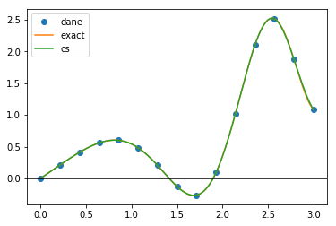

```python
# Przykład testu funkcji CubicSpline
# Dane (x_i, y_i) wygenerujemy z f(x)=x-1+cos(x**2)

xt1 = np.linspace(0, 3, num=15, endpoint=True)
yt1=xt1-1+np.cos(xt1**2)
cs = CubicSpline(xt1, yt1)
plt.plot(xt1, yt1,'o')
xd1 = np.linspace(0, 3, num=150, endpoint=True)
plt.plot(xd1, xd1-1+np.cos(xd1**2))
plt.plot(xd1, cs(xd1))
plt.legend(['dane', 'exact', 'cs'], loc='best')
plt.axhline(y=0,color='k')
plt.show()
```

```python
# obliczenie pierwiastków z CubicSpline
pierw=cs.roots(0, 3)
for r in pierw:
    print("%12.8f  %12.8e" %( r,cs(r)) )
```

```
 -1.17228658  1.11022302e-16
  0.00000000  0.00000000e+00
  1.41267086  -6.41847686e-17
  1.89711162  -2.11636264e-16
```

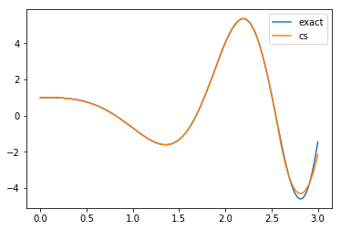

```python
#obliczenie pierwszej pochodnej
# dokładna
plt.plot(xd1,1-2*xd1*np.sin(xd1**2))
# z funkcji sklejanych
plt.plot(xd1, cs(xd1,1))
plt.legend(['exact', 'cs'], loc='best')
plt.show()
```

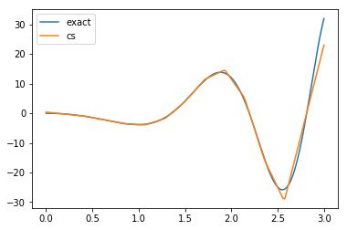

```python
#obliczenie drugiej pochodnej
# dokładna
plt.plot(xd1,-2*np.sin(xd1**2)-4*xd1**2*np.cos(xd1**2))
# z funkcji sklejanych
plt.plot(xd1, cs(xd1,2))
plt.legend(['exact', 'cs'], loc='best')
plt.show()
```

```python
# Obliczenie całki z funkcji interpolującej w przedziale od 0 do 3
# Wynik całki z funkcji dokładnej: 2.202864
print(cs.integrate(0, 3))
```

```
2.205054224443963
```

Przykład problemu sztywnego - wartości w węzłach po szybkim wzroście osiągają prawie jednakowe wartości w końcowej częsci badanego zakresu x.

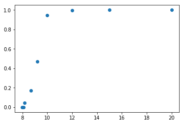

```python
# przykład sztywnego problemu

xs=np.array([7.99, 8.09, 8.19, 8.7, 9.2, 10.0, 12.0, 15.0, 20.0])
ys=np.array([0.0, 2.76429e-5, 4.37498e-2, 0.169183, 0.469428, 0.94374, \
             0.998636, 0.999919, 0.999994])
plt.plot(xs, ys,'o')
plt.show()
```

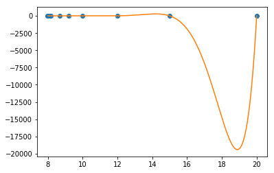

```python
# przykład sztywnego problemu
# Interpolacja Lagranża

plt.plot(xs, ys,'o')
sl1 = lagrange(xs, ys)
xsd = np.linspace(8, 20, num=200, endpoint=True)
plt.plot(xsd, sl1(xsd))
plt.show()
# Poniższy wykres pokazuje, że interpolacja Lagranża całkowicie zawodzi w tym przypadku
```

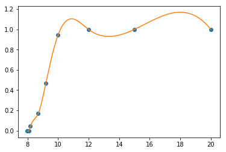

```python
# przykład sztywnego problemu
# CubicSpline
plt.plot(xs, ys,'o')
css = CubicSpline(xs, ys)
plt.plot(xsd, css(xsd))
plt.show()
# Widzimy niżej, że interpolacja CubicSpline prowadzi do oscylacji
# między kilkoma końcowymi węzłami
```

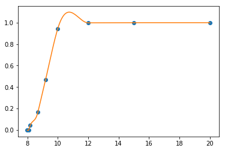

```python
# przykład sztywnego problemu
# Akima CS
from scipy.interpolate import Akima1DInterpolator
plt.plot(xs, ys,'o')
aks = Akima1DInterpolator(xs, ys)
plt.plot(xsd, aks(xsd))
plt.show()

# Interpolacja Akimy radzi sobie lepiej niż CubicSpline ale ma jedno "wybrzuszenie"
```

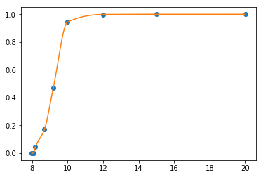

```python
# przykład sztywnego problemu
# Piecewise Cubic Hermite Interpolating Polynomial
from scipy.interpolate import PchipInterpolator
pch = PchipInterpolator(xs, ys)
plt.plot(xs, ys,'o')
plt.plot(xsd, pch(xsd))
plt.show()
```

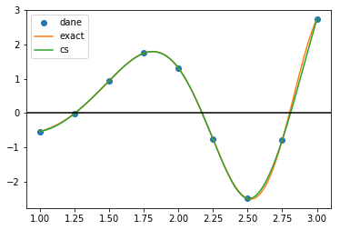

```python
# trzeci przykład użycia CubicSpline() dla kilku punktów z f(x)=-x*cos(x**2)
zx1 = np.linspace(1, 3, num=9, endpoint=True)
zy1=-zx1*np.cos(zx1**2)
zcs = CubicSpline(zx1, zy1)
plt.plot(zx1, zy1,'o')
zd1 = np.linspace(1, 3, num=150, endpoint=True)
plt.plot(zd1, -zd1*np.cos(zd1**2))
plt.plot(zd1, zcs(zd1))
plt.legend(['dane', 'exact', 'cs'], loc='best')
plt.axhline(y=0,color='k')
plt.show()
# na wykresie widać róznice między dokładną funkcją a funkcjami sklejanymi dla x>2.5
# ze względu na zbyt duże zmiany funkcji między węzłami
# Zwiększenie liczby węzłów np. do 15 poprawi to dopasowanie
```

```python
#pierwiastki
zcs.roots(1,3)
```

```
array([0.69413488, 1.25318517, 2.17019753, 2.81001554, 3.63508439])
```

```python
#pochodna w x=2.1
print(zcs(2.1,1))
```

```
-8.159088793026699
```

Przykład interpolacji dwuwymiarowej za pomocą funkcji scipy.interpolate.griddata().

https://docs.scipy.org/doc/scipy/reference/generated/scipy.interpolate.griddata.html#scipy.interpolate.griddata

Z obrazu o 40000 pikseli wybierzemy losowo 1000 pikseli i odtworzymy ten obraz wykorzystując dwuwymiarową interpolację

```python
# dwuwymiarowa funkcja do konstrukcji obrazu
def func(x, y):
    return x*(1-x)*np.cos(4*np.pi*x) * np.sin(4*np.pi*y**2)**2
```

```python
from scipy.interpolate import griddata
# dwuwymiarowa siatka w kwadracie jednostkowym
grid_x, grid_y = np.mgrid[0:1:200j, 0:1:200j]
# losowy wybór 1000 punktów z kwadratu jednostkowego
points = np.random.rand(1000, 2)
# wartości funkcji w losowych punktach
values = func(points[:,0], points[:,1])
```

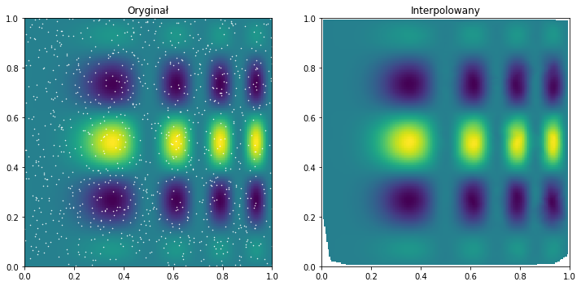

```python
# obraz oryginalny z zaznaczonymi punktami losowymi
plt.subplot(121)
plt.imshow(func(grid_x, grid_y), extent=(0,1,0,1), origin='lower')
plt.plot(points[:,0], points[:,1], 'w.', ms=1)
plt.title('Oryginał')
# Obraz odtworzony z 1000 punktów
plt.subplot(122)
# dwuwymiarowa interpolacja
grid_c = griddata(points, values, (grid_x, grid_y), method='cubic')

plt.imshow(grid_c, extent=(0,1,0,1), origin='lower')
plt.title('Interpolowany')
plt.gcf().set_size_inches(12, 12)
plt.show()
```

## Aproksymacja. Metoda najmniejszych kwadratów

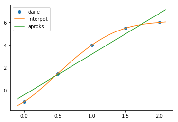

```python
#Różnica między interpolacją i aproksymacją
ax1=np.array([ 0, 0.5, 1, 1.5, 2],dtype=float)
ay1=np.array([-1, 1.5, 4, 5.5, 6],dtype=float)
wiel_4 = lagrange(ax1, ay1)
aw_1 = np.polyfit(ax1, ay1, 1)
axd = np.arange(-0.1, 2.1, 0.01)
paw_1=np.poly1d(aw_1)
plt.plot(ax1, ay1,'o')
plt.plot(axd, wiel_4(axd))
plt.plot(axd, paw_1(axd))
plt.legend(['dane','interpol,', 'aproks.'], loc='best')
plt.show()
```

### Dopasowanie funkcji do danych

Mając dane pomiarowe $(x_i,y_i)$, $i=0,1,\ldots,n$ szukamy gładkiej krzywej, która dobrze pasuje do tych danych. Krzywa ta powinna mieć prostą postać, żeby nie odtwarzać "szumu" związanego z błędami jakimi obarczone są dane pomiarowe.

Załóżmy, że funkcja f(x) zależy od m+1 parametrów $a_0, a_1,\ldots,a_m$, np. jest wielomianem stopnia m, z $m<n$. Wybór postaci funkcji powinna podpowiadać teoria związana z eksperymentem.

Metoda najmniejszych kwadratów określa parametry $a_0, a_1,\ldots,a_m$ z warunku minimum funkcji

$$ S(a_0, a_1,\ldots,a_m)=\sum_{i=0}^n{\left(y_i-f(x_i)\right)^2}, $$

który prowadzi do układu równań

$$ \begin{array}{c} \frac{\partial S}{\partial a_1}=0\\ \frac{\partial S}{\partial a_2}=0\\ \vdots \\ \frac{\partial S}{\partial a_m}=0 \end{array} $$

Ogólnie, jest to układ równań nieliniowych ze względu na parametry $a_0, a_1,\ldots,a_m$. Jednak, dla funkcji liniowej $f(x)=a_1 x +a_0$ czy wielomianowej $f(x)=a_m x^m+\ldots+a_1 x+a_0$ ten układ jest liniowym układem równań, łatwym do rozwiązania.

Do oceny rozrzutu danych wokół krzywej dopasowania służy standardowe odchylenie

$$ \sigma=\sqrt{\frac{S}{n-m}} $$

Wykorzystamy teraz funkcję polyfit()z Numpy

https://docs.scipy.org/doc/numpy/reference/generated/numpy.polyfit.html#numpy.polyfit

i nieliniową metodę najmniejszych kwadratów curve_fit() z Scipy

https://docs.scipy.org/doc/scipy/reference/generated/scipy.optimize.curve_fit.html#scipy.optimize.curve_fit

do rozwiązania kilku przykładowych zadań.

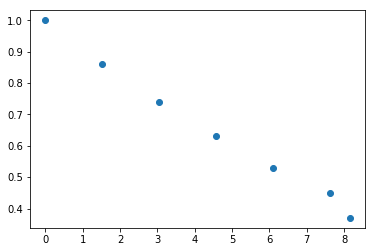

```python
# dane
ccx=[0,1.52,3.05,4.58,6.1,7.63,8.15]
ccy=[1,0.86,0.74,0.63,0.53,0.45,0.37]
# wykres
plt.plot(ccx, ccy,'o')

plt.show()
```

```
[ 0.00154621 -0.08632592  0.99400717]
```

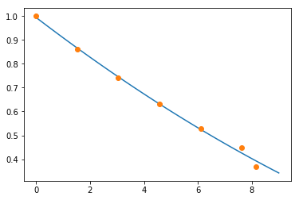

```python
# Dopasowanie funkcji kwadratowej za pomocą polyfit()z Numpy
fk1 = np.polyfit(ccx,ccy, 2)
# fk1 zawiera współczynniki wielomianu stopnia 2
print(fk1)
# wygodnie jest korzystać z wielomianu o tych współczynnikach
wiel1=np.poly1d(fk1)
xx=np.linspace(0, 9, num=100, endpoint=True)
plt.plot(xx, wiel1(xx))
plt.plot(ccx, ccy,'o')
plt.show()
```

```python
# Żeby mieć dodatkowe informacje o tym dopasowaniu użyjemy opcji full=True

fk1,tres,trank,tsv,trcond  = np.polyfit(ccx,ccy, 2,full=True)
s=tres[0]
print('S=',s)
# Znając S możemy obliczyć standardowe odchylenie
print('sigma=',np.sqrt(s/(len(ccx)-1-2)))
```

```
S= 0.0012724405075429043
sigma= 0.01783564203738475
```

```python
# teraz do tego samego problemu użyjemy curve_fit z scipy.optimize
from scipy.optimize import curve_fit

# najpierw deklarujemy postać funkcji, którą dopasujemy do danych
def funq(x,a,b,c):
    return a*x*x+b*x+c

# uzywamy curve_fit()
parm1,pcov=curve_fit(funq,ccx,ccy)
print(parm1)
#parm1 zawiera obliczone parametry a,b,c
```

```
[ 0.00154621 -0.08632592  0.99400717]
```

```python
pcov
# pcov to macierz kowariancji
# diagonalne składowe to wariancje parametrów, pozwalają oszacować ich dokładność
```

```
array([[ 1.09352214e-06, -9.19913178e-06,  1.04037193e-05],
       [-9.19913178e-06,  8.29786111e-05, -1.12308437e-04],
       [ 1.04037193e-05, -1.12308437e-04,  2.54307895e-04]])
```

```python
for i in range(len(parm1)):
    print('a[',len(parm1)-1-i,']=',parm1[i],'+-',np.sqrt(pcov[i,i]))
```

```
a[ 2 ]= 0.0015462100386359554 +- 0.0010457160872093996
a[ 1 ]= -0.08632591867328854 +- 0.009109259635211513
a[ 0 ]= 0.9940071695132638 +- 0.015947034059242884
```

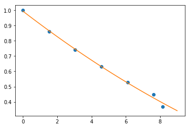

```python
plt.plot(ccx, ccy,'o')
xx=np.linspace(0, 9, num=100, endpoint=True)
plt.plot(xx, funq(xx,*parm1))
plt.show()
```

```python
# drugi przykład, sprawdzimy jaki wybrać wielomian stopnia <5 do poniższych danych
# obliczając odchylenie standardowe
xdf=np.array([-0.04, 0.93, 1.95, 2.9, 3.83, 5, 5.98, 7.05, 8.21, 9.08, 10.09])
ydf=np.array([-8.66,-6.44,-4.36,-3.27,-0.88,0.87,3.31,4.63,6.19,7.4,8.85])
for i in range(1,5):
    tp,tres,trank,tsv,trcond = np.polyfit(xdf, ydf, i, full=True)
    twiel=np.poly1d(tp)
    #s2=((twiel(xdf)-ydf)**2).sum()
    print('i=',i,' S=',tres[0],   ' sigma=',np.sqrt(tres[0]/(10-i)))
```

```
i= 1  S= 2.3526544400571225  sigma= 0.5112788367370938
i= 2  S= 0.7737285550297337  sigma= 0.3109920728551079
i= 3  S= 0.7144803060024009  sigma= 0.31948179156753226
i= 4  S= 0.7135639396702821  sigma= 0.3448584104794029
```

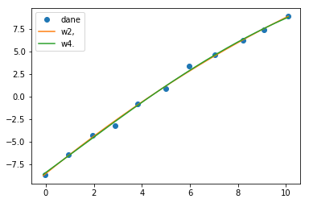

```python
# Najmniejsze standardowe odchylenie otrzymujemy dla wielomianu 2 stopnia
# wykreślimy dane i dwa wielomiany n=2 i n=4
tp2 = np.polyfit(xdf, ydf, 2)
tw2=np.poly1d(tp2)
tp4 = np.polyfit(xdf, ydf, 4)
tw4=np.poly1d(tp4)
plt.plot(xdf, ydf,'o')
fxd = np.arange(-0.1, 10.1, 0.01)
plt.plot(fxd, tw2(fxd))
plt.plot(fxd, tw4(fxd))
plt.legend(['dane','w2,', 'w4.'], loc='best')
plt.show()
```

### Dopasowanie funkcji do danych z wagami

Jeśli dane mają określone wagi $w_0, w_1,\ldots,w_n$ to mnimalizuje się funkcję $$ S(a_0, a_1,\ldots,a_m)=\sum_{i=0}^n{w_i^2\left(y_i-f(x_i)\right)^2} $$ żeby obliczyć optymalne wartości parametrów $a_0, a_1,\ldots,a_m$

Np. dla funkcji liniowej $f(x)=ax+b$

$$\bar{x}=\frac{\sum_i{w_i^2x_i}}{\sum_i{w_i^2}}$$$$\bar{y}=\frac{\sum_i{w_i^2y_i}}{\sum_i{w_i^2}}$$$$ b=\bar{y}-a\bar{x} $$$$a=\frac{\sum_i{w_i^2y_i(x_i-\bar{x})}}{\sum_i{w_i^2x_i(x_i-\bar{x})}}$$

Przykład.

Dla następujących danych

\begin{array}{|c|c|c|c||c|c|} \hline x&1.2& 2.8& 4.3& 5.4& 6.8& 7.9\\ \hline y & 7.5& 16.1& 38.9& 67& 146.6& 266.2\\ \hline \end{array}

dopasujemy funkcję

\begin{equation}\label{eq:} f(x)=b e^{ax} \end{equation}

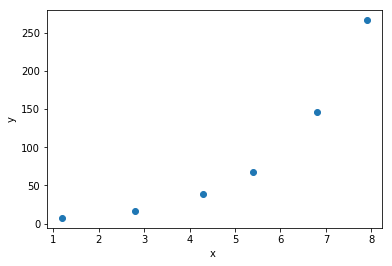

```python
#do poniższych danych dopasujemy funkcję f(x)=b exp(ax)
ex=np.array([1.2, 2.8, 4.3, 5.4, 6.8, 7.9])
ey=np.array([7.5, 16.1, 38.9, 67, 146.6, 266.2])
plt.plot(ex,ey,'o')
plt.xlabel('x ')
plt.ylabel('y')
plt.show()
```

Wygodniej jest przejść od $(x_i, y_i)$ do $(x_i, ln(y_i))$ Dzięki temu możemy uzyć funkcji

\begin{equation}\label{eq:lnreg} ln(f(x))= ln(b)+ax \end{equation}

do liniowej regresji.

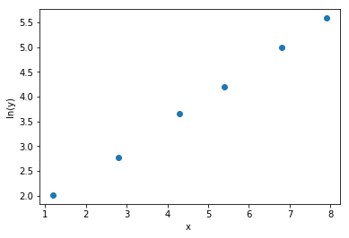

```python
# wykres funkcji ln(f(x))= ln(b)+ax
lgey=np.log(ey)
plt.plot(ex,lgey,'o')
plt.xlabel('x ')
plt.ylabel('ln(y)')
plt.show()
```

Zastosujemy teraz polyfit() do $(x_i, ln(y_i))$

```python
tp1 = np.polyfit(ex,lgey, 1)
a1=tp1[0]
b1=np.exp(tp1[1])
print('a1=',a1,'  b1=',b1)
# obliczymy S i sigma dla residuów  y_i- f(x_i)
s1=((ey-b1*np.exp(a1*ex))**2).sum()
sigma1=np.sqrt(s1/(len(ex)-2))
print('S=',s1,'  sigma=',sigma1)
```

```
a1= 0.5365836969710379   b1= 3.7888579604822246
S= 17.625892678045393   sigma= 2.09916011049928
```

Teraz dopasujemy tę samą funkcję do danych z wagami $w_i=y_i$ żeby obniżyć sumę kwadratów residuów.

Jeśli

\begin{equation}\label{eq:tym1} s= \sum_i{r_i^2},\;\; \text{gdzie}\;\; r_i=y_i-f(x_i) \end{equation}

to dla ln(y_i)

\begin{equation}\label{eq:tym2} s_{ln}=\sum_i{[ln(y_i)-ln(f(x_i))]^2}= \sum_i{l_i^2} \end{equation}

gdzie

\begin{equation}\label{eq:tym3} l_i=ln(y_i)-ln(f(x_i)). \end{equation}

Podstawiając $y_i-r_i$ za $f(x_i)$ do (\ref{eq:tym3}) dostaniemy

\begin{equation}\label{eq:tym4} l_i=ln(y_i)-ln(y_i-r_i)=-ln\frac{y_i-r_i}{y_i}=-ln(1-\frac{r_i}{y_i}) \end{equation}

Zakładając, że $r_i/y_i <<1$ otrzymamy

\begin{equation}\label{eq:tym5} l_i\approx r_i/y_i \end{equation}

Stąd widać, że wprowadzając wagi $w_i=y_i$ do (\ref{eq:tym2}) dostaniemy

\begin{equation}\label{eq:tym6} s_{ln}= \sum_i{w_i^2l_i^2}\approx \sum_i{r_i^2} \end{equation}

Innymi słowy, minimalizując kawadraty residuów dla $ln(y_i)$ z wagami $w_i=y_i$ otrzymamy również minimum kwadratów residuów $y_i$.

```python
#fitowanie z wagami
tp2 = np.polyfit(ex,lgey, 1,w=ey)
a2=tp2[0]
b2=np.exp(tp2[1])
print('a2=',a2,'  b2=',b2)
# obliczymy S i sigma dla y_i- f(x_i)
s2=((ey-b2*np.exp(a2*ex))**2).sum()
sigma2=np.sqrt(s2/(len(ex)-2))
print('S=',s2,'  sigma=',sigma2)
```

```
a2= 0.5439581915040762   b2= 3.6218188275039416
S= 4.1858448971788595   sigma= 1.0229668735079913
```

Porównując te wyniki z fitowaniem bez wag

```python
print('a1=',a1,'  b1=',b1)
print('S=',s1,'  sigma=',sigma1)
```

```
a1= 0.5365836969710379   b1= 3.7888579604822246
S= 17.625892678045393   sigma= 2.09916011049928
```

Widzimy, że lepsze rezultaty dało fitowanie z wagami (mniejsze wartości S i sigma).

Sprawdźmy, jak różnią się parametry funkcji otrzymane w tych podejściach

```python
print((a1-a2)/a2,'  ',(b1-b2)/b2)
```

```
-0.013557098042125959    0.046120234317021815
```

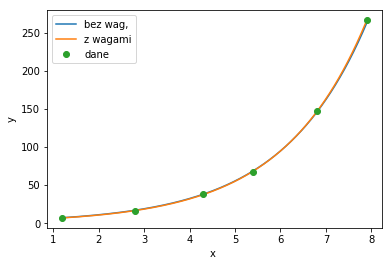

```python
# Graficzne porównanie tych dwóch podejsc
exd=np.arange(1.2,7.9,0.01)
plt.plot(exd,b1*np.exp(a1*exd))
plt.plot(exd,b2*np.exp(a2*exd))
plt.plot(ex,ey,'o')
plt.legend(['bez wag,', 'z wagami','dane'], loc='best')
plt.xlabel('x ')
plt.ylabel('y')
plt.show()
```

Zastosujemy jeszcze trzecie podejście wykorzystując nieliniową metodę najmniejszych kwadratów - curve_fit(), która nie wymaga przechodzenia do $ln(y_i)$.

Najpierw deklarujemy funkcję, którą chcemy dopasować do danych.

```python
def fexp(x,a,b):
    return b*np.exp(a*x)

#Następnie używamy curve_fit()

parm3,pcov3=curve_fit(fexp,ex,ey)

# otrzymując szukane parametry [a,b]
print(parm3)
# oraz macierz kowariancji
print('\n',pcov3)
#a2= 0.543958191504   b2= 3.6218188275
```

```
[0.54424866 3.61373393]

 [[ 1.61425919e-05 -4.36017566e-04]
 [-4.36017566e-04  1.19153105e-02]]
```

```python
# Obliczymy S i sigma dla tej metody
s3=((ey-fexp(ex,*parm3) )**2).sum()
sigma3=np.sqrt(s3/(len(ex)-2))
print('S=',s3,'  sigma=',sigma3)
```

```
S= 4.1799901414232625   sigma= 1.0222512095154574
```

```python
# Wyniki tego dopasowania są praktycznie takie same  jak dla polyfit z wagami
# obliczymy róznicę parametrów otrzymanych tymi dwoma metodami
print((parm3[0]-a2)/a2,(parm3[1]-b2)/b2)
```

```
0.000533992126968123 -0.0022322745742107235
```